# Glue and S3 parameters

## Table analysis

The notebook uses the following Papermill parameters to update the notebook:

- `DatabaseName`: Name of the database
- `table_name`: Name of the table
- `partition_keys`: variables name to group to count the duplicates
- `keys`: Variable name to perform the grouping -> Only one variable for now, Variable name to perform the secondary grouping -> Only one variable for now
  - format: 'A,B'
- `proba`: Chi-square analysis probabilitity
- `y_var`: Continuous target variables
- `threshohld`: Percent of missing values. If the percentage of missing is above the threshold, their exclude from analysis.

Upload queries analytics

[output not shown]

[output cut: 24 more lines]

[output not shown]

## Check Duplicates

One of the most important step when creating a table is to check if the table contains duplicates. The cell below checks if the table generated before is empty of duplicates. The code uses the JSON file to create the query parsed in Athena.

You are required to define the group(s) that Athena will use to compute the duplicate. For instance, your table can be grouped by COL1 and COL2 (need to be string or varchar), then pass the list ['COL1', 'COL2']

|  | CNT | CNT_DUPLICATE |
| --- | --- | --- |
| 0 | 1 | 1229065 |

# Analytics

In this part, we are providing basic summary statistic. Since we have created the tables, we can parse the schema in Glue and use our json file to automatically generates the analysis.

The cells below execute the job in the key `ANALYSIS`. You need to change the `primary_key` and `secondary_key`

## Count missing values

|  | total_missing | total_missing_pct |
| --- | --- | --- |
| nb_obs | 1229065 | 100.00% |
| indu_2 | 0 | 0.00% |
| count_industry | 0 | 0.00% |
| count_city | 0 | 0.00% |
| count_ownership | 0 | 0.00% |
| captal_upper_bound | 0 | 0.00% |
| employ_upper_bound | 0 | 0.00% |
| output_upper_bound | 0 | 0.00% |
| geocode4_corr | 0 | 0.00% |
| firm | 0 | 0.00% |
| ownership | 0 | 0.00% |
| midput | 0 | 0.00% |
| captal | 0 | 0.00% |
| employ | 0 | 0.00% |
| output | 0 | 0.00% |
| year | 0 | 0.00% |
| tfp_op | 0 | 0.00% |

Remove from the analysis all variables with a count of missing values above 50%. Note that, we exclude the first value since it is `nb_obs`

```
[]
```

# Brief description table

In this part, we provide a brief summary statistic from the lattest jobs. For the continuous analysis with a primary/secondary key, please add the relevant variables you want to know the count and distribution

## Categorical Description

During the categorical analysis, we wil count the number of observations for a given group and for a pair.

### Count obs by group

- Index: primary group
- nb_obs: Number of observations per primary group value
- percentage: Percentage of observation per primary group value over the total number of observations

Returns the top 10 only

```
Nb of obs for firm, comment Firm ID
```

| firm | nb_obs | percentage |
| --- | --- | --- |
| 259398.0 | 7 | 0.00% |
| 314769.0 | 7 | 0.00% |
| 399169.0 | 7 | 0.00% |
| 294859.0 | 7 | 0.00% |
| 371083.0 | 7 | 0.00% |
| 396434.0 | 7 | 0.00% |
| 413302.0 | 7 | 0.00% |
| 323347.0 | 7 | 0.00% |
| 278728.0 | 7 | 0.00% |
| 322394.0 | 7 | 0.00% |

```
Nb of obs for year, comment
```

| year | nb_obs | percentage |
| --- | --- | --- |
| 2007 | 232614 | 18.93% |
| 2006 | 221746 | 18.04% |
| 2005 | 205671 | 16.73% |
| 2004 | 201807 | 16.42% |
| 2003 | 141776 | 11.54% |
| 2002 | 115069 | 9.36% |
| 2001 | 110382 | 8.98% |

```
Nb of obs for ownership, comment firm s ownership
```

| ownership | nb_obs | percentage |
| --- | --- | --- |
| PRIVATE | 712483 | 57.97% |
| COLLECTIVE | 153112 | 12.46% |
| FOREIGN | 146438 | 11.91% |
| HTM | 139269 | 11.33% |
| SOE | 77763 | 6.33% |

```
Nb of obs for geocode4_corr, comment
```

| geocode4_corr | nb_obs | percentage |
| --- | --- | --- |
| 3101 | 70158 | 5.71% |
| 3302 | 39449 | 3.21% |
| 3205 | 38416 | 3.13% |
| 3301 | 34009 | 2.77% |
| 3303 | 28823 | 2.35% |
| 3202 | 26970 | 2.19% |
| 4401 | 26851 | 2.18% |
| 1101 | 24936 | 2.03% |
| 4403 | 23686 | 1.93% |
| 1201 | 22370 | 1.82% |

```
Nb of obs for indu_2, comment
```

| indu_2 | nb_obs | percentage |
| --- | --- | --- |
| 17 | 105041 | 8.55% |
| 35 | 93685 | 7.62% |
| 31 | 90806 | 7.39% |
| 26 | 83810 | 6.82% |
| 34 | 67483 | 5.49% |
| 18 | 61951 | 5.04% |
| 39 | 61191 | 4.98% |
| 30 | 55786 | 4.54% |
| 13 | 55556 | 4.52% |
| 37 | 54806 | 4.46% |

```
Nb of obs for output_upper_bound, comment
```

| output_upper_bound | nb_obs | percentage |
| --- | --- | --- |
| 737279 | 232614 | 18.93% |
| 655359 | 221746 | 18.04% |
| 557055 | 205671 | 16.73% |
| 458751 | 201807 | 16.42% |
| 483327 | 141776 | 11.54% |
| 417791 | 115069 | 9.36% |
| 385023 | 110382 | 8.98% |

```
Nb of obs for employ_upper_bound, comment
```

| employ_upper_bound | nb_obs | percentage |
| --- | --- | --- |
| 1535 | 427417 | 34.78% |
| 1919 | 256845 | 20.90% |
| 1407 | 232614 | 18.93% |
| 1503 | 201807 | 16.42% |
| 2047 | 110382 | 8.98% |

```
Nb of obs for captal_upper_bound, comment
```

| captal_upper_bound | nb_obs | percentage |
| --- | --- | --- |
| 151551 | 374390 | 30.46% |
| 143359 | 221746 | 18.04% |
| 139263 | 205671 | 16.73% |
| 131071 | 201807 | 16.42% |
| 159743 | 115069 | 9.36% |
| 145407 | 110382 | 8.98% |

```
Nb of obs for count_ownership, comment Number of ownerships per firm
```

| count_ownership | nb_obs | percentage |
| --- | --- | --- |
| 1 | 977044 | 79.49% |
| 2 | 227653 | 18.52% |
| 3 | 23671 | 1.93% |
| 4 | 683 | 0.06% |
| 5 | 14 | 0.00% |

```
Nb of obs for count_city, comment Number of cities per firm
```

| count_city | nb_obs | percentage |
| --- | --- | --- |
| 1 | 1227895 | 99.90% |
| 2 | 1150 | 0.09% |
| 3 | 20 | 0.00% |

```
Nb of obs for count_industry, comment Number of industries per firm
```

| count_industry | nb_obs | percentage |
| --- | --- | --- |
| 1 | 665204 | 54.12% |
| 2 | 415254 | 33.79% |
| 3 | 129938 | 10.57% |
| 4 | 17265 | 1.40% |
| 5 | 1328 | 0.11% |
| 6 | 76 | 0.01% |

### Count obs by two pair

You need to pass the primary group in the cell below

- Index: primary group
- Columns: Secondary key -> All the categorical variables in the dataset
- nb_obs: Number of observations per primary group value
- Total: Total number of observations per primary group value (sum by row)
- percentage: Percentage of observations per primary group value over the total number of observations per primary group value (sum by row)

Returns the top 10 only

```
Nb of obs for the primary group year and firm, details Firm ID
```

| year firm | nb_obs 2001 | nb_obs 2002 | nb_obs 2003 | nb_obs 2004 | nb_obs 2005 | nb_obs 2006 | nb_obs 2007 | total | percentage 2001 | percentage 2002 | percentage 2003 | percentage 2004 | percentage 2005 | percentage 2006 | percentage 2007 |
| --- | --- | --- | --- | --- | --- | --- | --- | --- | --- | --- | --- | --- | --- | --- | --- |
| 249462.0 | 0.00 | 0.00 | 0.00 | 1.00 | 1.00 | 1.00 | 1.00 | 4.00 | 0.00% | 0.00% | 0.00% | 25.00% | 25.00% | 25.00% | 25.00% |
| 326699.0 | 1.00 | 1.00 | 1.00 | 1.00 | 1.00 | 1.00 | 1.00 | 7.00 | 14.29% | 14.29% | 14.29% | 14.29% | 14.29% | 14.29% | 14.29% |
| 332290.0 | 0.00 | 0.00 | 1.00 | 1.00 | 1.00 | 1.00 | 1.00 | 5.00 | 0.00% | 0.00% | 20.00% | 20.00% | 20.00% | 20.00% | 20.00% |
| 332291.0 | 0.00 | 0.00 | 1.00 | 1.00 | 0.00 | 1.00 | 0.00 | 3.00 | 0.00% | 0.00% | 33.33% | 33.33% | 0.00% | 33.33% | 0.00% |
| 368228.0 | 0.00 | 0.00 | 0.00 | 1.00 | 1.00 | 0.00 | 0.00 | 2.00 | 0.00% | 0.00% | 0.00% | 50.00% | 50.00% | 0.00% | 0.00% |
| 425295.0 | 0.00 | 1.00 | 1.00 | 1.00 | 1.00 | 1.00 | 1.00 | 6.00 | 0.00% | 16.67% | 16.67% | 16.67% | 16.67% | 16.67% | 16.67% |
| 542023.0 | 0.00 | 0.00 | 0.00 | 0.00 | 0.00 | 0.00 | 1.00 | 1.00 | 0.00% | 0.00% | 0.00% | 0.00% | 0.00% | 0.00% | 100.00% |

```
Nb of obs for the primary group year and ownership, details firm s ownership
```

| year | nb_obs 2001 | nb_obs 2002 | nb_obs 2003 | nb_obs 2004 | nb_obs 2005 | nb_obs 2006 | nb_obs 2007 | total | percentage 2001 | percentage 2002 | percentage 2003 | percentage 2004 | percentage 2005 | percentage 2006 | percentage 2007 |
| --- | --- | --- | --- | --- | --- | --- | --- | --- | --- | --- | --- | --- | --- | --- | --- |
| SOE | 14,468.00 | 12,795.00 | 12,144.00 | 11,028.00 | 9,868.00 | 8,978.00 | 8,482.00 | 77,763.00 | 18.61% | 16.45% | 15.62% | 14.18% | 12.69% | 11.55% | 10.91% |
| HTM | 10,432.00 | 11,457.00 | 14,313.00 | 23,534.00 | 24,070.00 | 26,224.00 | 29,239.00 | 139,269.00 | 7.49% | 8.23% | 10.28% | 16.90% | 17.28% | 18.83% | 20.99% |
| FOREIGN | 14,603.00 | 15,315.00 | 17,696.00 | 23,451.00 | 23,373.00 | 24,781.00 | 27,219.00 | 146,438.00 | 9.97% | 10.46% | 12.08% | 16.01% | 15.96% | 16.92% | 18.59% |
| COLLECTIVE | 31,475.00 | 25,930.00 | 25,054.00 | 20,833.00 | 19,057.00 | 16,260.00 | 14,503.00 | 153,112.00 | 20.56% | 16.94% | 16.36% | 13.61% | 12.45% | 10.62% | 9.47% |
| PRIVATE | 39,404.00 | 49,572.00 | 72,569.00 | 122,961.00 | 129,303.00 | 145,503.00 | 153,171.00 | 712,483.00 | 5.53% | 6.96% | 10.19% | 17.26% | 18.15% | 20.42% | 21.50% |

```
Nb of obs for the primary group year and geocode4_corr, details
```

| year geocode4_corr | nb_obs 2001 | nb_obs 2002 | nb_obs 2003 | nb_obs 2004 | nb_obs 2005 | nb_obs 2006 | nb_obs 2007 | total | percentage 2001 | percentage 2002 | percentage 2003 | percentage 2004 | percentage 2005 | percentage 2006 | percentage 2007 |
| --- | --- | --- | --- | --- | --- | --- | --- | --- | --- | --- | --- | --- | --- | --- | --- |
| 1101 | 2,602.00 | 2,814.00 | 2,796.00 | 4,228.00 | 4,151.00 | 4,240.00 | 4,105.00 | 24,936.00 | 10.43% | 11.28% | 11.21% | 16.96% | 16.65% | 17.00% | 16.46% |
| 1201 | 3,166.00 | 2,458.00 | 2,535.00 | 3,916.00 | 3,283.00 | 3,365.00 | 3,647.00 | 22,370.00 | 14.15% | 10.99% | 11.33% | 17.51% | 14.68% | 15.04% | 16.30% |
| 3101 | 7,781.00 | 7,663.00 | 8,880.00 | 12,200.00 | 11,433.00 | 11,437.00 | 10,764.00 | 70,158.00 | 11.09% | 10.92% | 12.66% | 17.39% | 16.30% | 16.30% | 15.34% |
| 3202 | 2,569.00 | 2,803.00 | 3,303.00 | 5,880.00 | 3,919.00 | 4,247.00 | 4,249.00 | 26,970.00 | 9.53% | 10.39% | 12.25% | 21.80% | 14.53% | 15.75% | 15.75% |
| 3205 | 3,047.00 | 3,299.00 | 3,754.00 | 9,148.00 | 5,495.00 | 6,629.00 | 7,044.00 | 38,416.00 | 7.93% | 8.59% | 9.77% | 23.81% | 14.30% | 17.26% | 18.34% |
| 3301 | 2,817.00 | 3,236.00 | 3,894.00 | 6,137.00 | 5,950.00 | 6,077.00 | 5,898.00 | 34,009.00 | 8.28% | 9.52% | 11.45% | 18.05% | 17.50% | 17.87% | 17.34% |
| 3302 | 3,021.00 | 3,409.00 | 4,004.00 | 6,826.00 | 7,179.00 | 7,706.00 | 7,304.00 | 39,449.00 | 7.66% | 8.64% | 10.15% | 17.30% | 18.20% | 19.53% | 18.52% |
| 3303 | 2,547.00 | 3,162.00 | 3,341.00 | 4,832.00 | 4,768.00 | 5,042.00 | 5,131.00 | 28,823.00 | 8.84% | 10.97% | 11.59% | 16.76% | 16.54% | 17.49% | 17.80% |
| 4401 | 3,606.00 | 3,603.00 | 3,798.00 | 4,053.00 | 4,146.00 | 3,980.00 | 3,665.00 | 26,851.00 | 13.43% | 13.42% | 14.14% | 15.09% | 15.44% | 14.82% | 13.65% |
| 4403 | 1,385.00 | 1,268.00 | 1,970.00 | 4,584.00 | 4,397.00 | 4,444.00 | 5,638.00 | 23,686.00 | 5.85% | 5.35% | 8.32% | 19.35% | 18.56% | 18.76% | 23.80% |

```
Nb of obs for the primary group year and indu_2, details
```

| year indu_2 | nb_obs 2001 | nb_obs 2002 | nb_obs 2003 | nb_obs 2004 | nb_obs 2005 | nb_obs 2006 | nb_obs 2007 | total | percentage 2001 | percentage 2002 | percentage 2003 | percentage 2004 | percentage 2005 | percentage 2006 | percentage 2007 |
| --- | --- | --- | --- | --- | --- | --- | --- | --- | --- | --- | --- | --- | --- | --- | --- |
| 13 | 5,344.00 | 1,021.00 | 6,890.00 | 9,150.00 | 10,158.00 | 11,161.00 | 11,832.00 | 55,556.00 | 9.62% | 1.84% | 12.40% | 16.47% | 18.28% | 20.09% | 21.30% |
| 17 | 8,728.00 | 9,531.00 | 11,418.00 | 18,810.00 | 17,943.00 | 19,455.00 | 19,156.00 | 105,041.00 | 8.31% | 9.07% | 10.87% | 17.91% | 17.08% | 18.52% | 18.24% |
| 18 | 6,480.00 | 7,169.00 | 8,009.00 | 9,831.00 | 9,787.00 | 10,291.00 | 10,384.00 | 61,951.00 | 10.46% | 11.57% | 12.93% | 15.87% | 15.80% | 16.61% | 16.76% |
| 26 | 7,988.00 | 8,522.00 | 9,754.00 | 13,234.00 | 13,738.00 | 14,845.00 | 15,729.00 | 83,810.00 | 9.53% | 10.17% | 11.64% | 15.79% | 16.39% | 17.71% | 18.77% |
| 30 | 5,053.00 | 5,572.00 | 6,397.00 | 9,175.00 | 9,253.00 | 10,029.00 | 10,307.00 | 55,786.00 | 9.06% | 9.99% | 11.47% | 16.45% | 16.59% | 17.98% | 18.48% |
| 31 | 9,122.00 | 9,730.00 | 11,037.00 | 13,988.00 | 14,815.00 | 15,568.00 | 16,546.00 | 90,806.00 | 10.05% | 10.72% | 12.15% | 15.40% | 16.32% | 17.14% | 18.22% |
| 34 | 6,818.00 | 7,338.00 | 7,522.00 | 10,777.00 | 10,754.00 | 11,830.00 | 12,444.00 | 67,483.00 | 10.10% | 10.87% | 11.15% | 15.97% | 15.94% | 17.53% | 18.44% |
| 35 | 7,613.00 | 8,227.00 | 9,891.00 | 15,762.00 | 15,883.00 | 17,560.00 | 18,749.00 | 93,685.00 | 8.13% | 8.78% | 10.56% | 16.82% | 16.95% | 18.74% | 20.01% |
| 37 | 4,911.00 | 5,393.00 | 6,366.00 | 9,006.00 | 8,964.00 | 9,772.00 | 10,394.00 | 54,806.00 | 8.96% | 9.84% | 11.62% | 16.43% | 16.36% | 17.83% | 18.97% |
| 39 | 0.00 | 83.00 | 8,348.00 | 12,790.00 | 12,368.00 | 13,415.00 | 14,187.00 | 61,191.00 | 0.00% | 0.14% | 13.64% | 20.90% | 20.21% | 21.92% | 23.18% |

```
Nb of obs for the primary group year and output_upper_bound, details
```

| year output_upper_bound | nb_obs 2001 | nb_obs 2002 | nb_obs 2003 | nb_obs 2004 | nb_obs 2005 | nb_obs 2006 | nb_obs 2007 | total | percentage 2001 | percentage 2002 | percentage 2003 | percentage 2004 | percentage 2005 | percentage 2006 | percentage 2007 |
| --- | --- | --- | --- | --- | --- | --- | --- | --- | --- | --- | --- | --- | --- | --- | --- |
| 385023 | 110,382.00 | 0.00 | 0.00 | 0.00 | 0.00 | 0.00 | 0.00 | 110,382.00 | 100.00% | 0.00% | 0.00% | 0.00% | 0.00% | 0.00% | 0.00% |
| 417791 | 0.00 | 115,069.00 | 0.00 | 0.00 | 0.00 | 0.00 | 0.00 | 115,069.00 | 0.00% | 100.00% | 0.00% | 0.00% | 0.00% | 0.00% | 0.00% |
| 458751 | 0.00 | 0.00 | 0.00 | 201,807.00 | 0.00 | 0.00 | 0.00 | 201,807.00 | 0.00% | 0.00% | 0.00% | 100.00% | 0.00% | 0.00% | 0.00% |
| 483327 | 0.00 | 0.00 | 141,776.00 | 0.00 | 0.00 | 0.00 | 0.00 | 141,776.00 | 0.00% | 0.00% | 100.00% | 0.00% | 0.00% | 0.00% | 0.00% |
| 557055 | 0.00 | 0.00 | 0.00 | 0.00 | 205,671.00 | 0.00 | 0.00 | 205,671.00 | 0.00% | 0.00% | 0.00% | 0.00% | 100.00% | 0.00% | 0.00% |
| 655359 | 0.00 | 0.00 | 0.00 | 0.00 | 0.00 | 221,746.00 | 0.00 | 221,746.00 | 0.00% | 0.00% | 0.00% | 0.00% | 0.00% | 100.00% | 0.00% |
| 737279 | 0.00 | 0.00 | 0.00 | 0.00 | 0.00 | 0.00 | 232,614.00 | 232,614.00 | 0.00% | 0.00% | 0.00% | 0.00% | 0.00% | 0.00% | 100.00% |

```
Nb of obs for the primary group year and employ_upper_bound, details
```

| year employ_upper_bound | nb_obs 2001 | nb_obs 2002 | nb_obs 2003 | nb_obs 2004 | nb_obs 2005 | nb_obs 2006 | nb_obs 2007 | total | percentage 2001 | percentage 2002 | percentage 2003 | percentage 2004 | percentage 2005 | percentage 2006 | percentage 2007 |
| --- | --- | --- | --- | --- | --- | --- | --- | --- | --- | --- | --- | --- | --- | --- | --- |
| 1407 | 0.00 | 0.00 | 0.00 | 0.00 | 0.00 | 0.00 | 232,614.00 | 232,614.00 | 0.00% | 0.00% | 0.00% | 0.00% | 0.00% | 0.00% | 100.00% |
| 1503 | 0.00 | 0.00 | 0.00 | 201,807.00 | 0.00 | 0.00 | 0.00 | 201,807.00 | 0.00% | 0.00% | 0.00% | 100.00% | 0.00% | 0.00% | 0.00% |
| 1535 | 0.00 | 0.00 | 0.00 | 0.00 | 205,671.00 | 221,746.00 | 0.00 | 427,417.00 | 0.00% | 0.00% | 0.00% | 0.00% | 48.12% | 51.88% | 0.00% |
| 1919 | 0.00 | 115,069.00 | 141,776.00 | 0.00 | 0.00 | 0.00 | 0.00 | 256,845.00 | 0.00% | 44.80% | 55.20% | 0.00% | 0.00% | 0.00% | 0.00% |
| 2047 | 110,382.00 | 0.00 | 0.00 | 0.00 | 0.00 | 0.00 | 0.00 | 110,382.00 | 100.00% | 0.00% | 0.00% | 0.00% | 0.00% | 0.00% | 0.00% |

```
Nb of obs for the primary group year and captal_upper_bound, details
```

| year captal_upper_bound | nb_obs 2001 | nb_obs 2002 | nb_obs 2003 | nb_obs 2004 | nb_obs 2005 | nb_obs 2006 | nb_obs 2007 | total | percentage 2001 | percentage 2002 | percentage 2003 | percentage 2004 | percentage 2005 | percentage 2006 | percentage 2007 |
| --- | --- | --- | --- | --- | --- | --- | --- | --- | --- | --- | --- | --- | --- | --- | --- |
| 131071 | 0.00 | 0.00 | 0.00 | 201,807.00 | 0.00 | 0.00 | 0.00 | 201,807.00 | 0.00% | 0.00% | 0.00% | 100.00% | 0.00% | 0.00% | 0.00% |
| 139263 | 0.00 | 0.00 | 0.00 | 0.00 | 205,671.00 | 0.00 | 0.00 | 205,671.00 | 0.00% | 0.00% | 0.00% | 0.00% | 100.00% | 0.00% | 0.00% |
| 143359 | 0.00 | 0.00 | 0.00 | 0.00 | 0.00 | 221,746.00 | 0.00 | 221,746.00 | 0.00% | 0.00% | 0.00% | 0.00% | 0.00% | 100.00% | 0.00% |
| 145407 | 110,382.00 | 0.00 | 0.00 | 0.00 | 0.00 | 0.00 | 0.00 | 110,382.00 | 100.00% | 0.00% | 0.00% | 0.00% | 0.00% | 0.00% | 0.00% |
| 151551 | 0.00 | 0.00 | 141,776.00 | 0.00 | 0.00 | 0.00 | 232,614.00 | 374,390.00 | 0.00% | 0.00% | 37.87% | 0.00% | 0.00% | 0.00% | 62.13% |
| 159743 | 0.00 | 115,069.00 | 0.00 | 0.00 | 0.00 | 0.00 | 0.00 | 115,069.00 | 0.00% | 100.00% | 0.00% | 0.00% | 0.00% | 0.00% | 0.00% |

```
Nb of obs for the primary group year and count_ownership, details Number of ownerships per firm
```

| year count_ownership | nb_obs 2001 | nb_obs 2002 | nb_obs 2003 | nb_obs 2004 | nb_obs 2005 | nb_obs 2006 | nb_obs 2007 | total | percentage 2001 | percentage 2002 | percentage 2003 | percentage 2004 | percentage 2005 | percentage 2006 | percentage 2007 |
| --- | --- | --- | --- | --- | --- | --- | --- | --- | --- | --- | --- | --- | --- | --- | --- |
| 1 | 81,697.00 | 84,256.00 | 104,845.00 | 161,748.00 | 165,368.00 | 182,678.00 | 196,452.00 | 977,044.00 | 8.36% | 8.62% | 10.73% | 16.55% | 16.93% | 18.70% | 20.11% |
| 2 | 25,700.00 | 27,669.00 | 33,291.00 | 36,279.00 | 36,517.00 | 35,435.00 | 32,762.00 | 227,653.00 | 11.29% | 12.15% | 14.62% | 15.94% | 16.04% | 15.57% | 14.39% |
| 3 | 2,896.00 | 3,050.00 | 3,539.00 | 3,675.00 | 3,682.00 | 3,530.00 | 3,299.00 | 23,671.00 | 12.23% | 12.88% | 14.95% | 15.53% | 15.55% | 14.91% | 13.94% |
| 4 | 87.00 | 92.00 | 99.00 | 103.00 | 102.00 | 101.00 | 99.00 | 683.00 | 12.74% | 13.47% | 14.49% | 15.08% | 14.93% | 14.79% | 14.49% |
| 5 | 2.00 | 2.00 | 2.00 | 2.00 | 2.00 | 2.00 | 2.00 | 14.00 | 14.29% | 14.29% | 14.29% | 14.29% | 14.29% | 14.29% | 14.29% |

```
Nb of obs for the primary group year and count_city, details Number of cities per firm
```

| year count_city | nb_obs 2001 | nb_obs 2002 | nb_obs 2003 | nb_obs 2004 | nb_obs 2005 | nb_obs 2006 | nb_obs 2007 | total | percentage 2001 | percentage 2002 | percentage 2003 | percentage 2004 | percentage 2005 | percentage 2006 | percentage 2007 |
| --- | --- | --- | --- | --- | --- | --- | --- | --- | --- | --- | --- | --- | --- | --- | --- |
| 1 | 110,277.00 | 114,952.00 | 141,618.00 | 201,620.00 | 205,477.00 | 221,540.00 | 232,411.00 | 1,227,895.00 | 8.98% | 9.36% | 11.53% | 16.42% | 16.73% | 18.04% | 18.93% |
| 2 | 104.00 | 116.00 | 155.00 | 184.00 | 190.00 | 202.00 | 199.00 | 1,150.00 | 9.04% | 10.09% | 13.48% | 16.00% | 16.52% | 17.57% | 17.30% |
| 3 | 1.00 | 1.00 | 3.00 | 3.00 | 4.00 | 4.00 | 4.00 | 20.00 | 5.00% | 5.00% | 15.00% | 15.00% | 20.00% | 20.00% | 20.00% |

```
Nb of obs for the primary group year and count_industry, details Number of industries per firm
```

| year count_industry | nb_obs 2001 | nb_obs 2002 | nb_obs 2003 | nb_obs 2004 | nb_obs 2005 | nb_obs 2006 | nb_obs 2007 | total | percentage 2001 | percentage 2002 | percentage 2003 | percentage 2004 | percentage 2005 | percentage 2006 | percentage 2007 |
| --- | --- | --- | --- | --- | --- | --- | --- | --- | --- | --- | --- | --- | --- | --- | --- |
| 1 | 40,627.00 | 33,408.00 | 48,893.00 | 115,033.00 | 122,751.00 | 143,108.00 | 161,384.00 | 665,204.00 | 6.11% | 5.02% | 7.35% | 17.29% | 18.45% | 21.51% | 24.26% |
| 2 | 50,733.00 | 59,027.00 | 68,884.00 | 64,031.00 | 61,455.00 | 58,377.00 | 52,747.00 | 415,254.00 | 12.22% | 14.21% | 16.59% | 15.42% | 14.80% | 14.06% | 12.70% |
| 3 | 16,461.00 | 19,843.00 | 21,132.00 | 19,968.00 | 18,797.00 | 17,673.00 | 16,064.00 | 129,938.00 | 12.67% | 15.27% | 16.26% | 15.37% | 14.47% | 13.60% | 12.36% |
| 4 | 2,370.00 | 2,584.00 | 2,659.00 | 2,570.00 | 2,470.00 | 2,385.00 | 2,227.00 | 17,265.00 | 13.73% | 14.97% | 15.40% | 14.89% | 14.31% | 13.81% | 12.90% |
| 5 | 180.00 | 196.00 | 197.00 | 194.00 | 187.00 | 192.00 | 182.00 | 1,328.00 | 13.55% | 14.76% | 14.83% | 14.61% | 14.08% | 14.46% | 13.70% |
| 6 | 11.00 | 11.00 | 11.00 | 11.00 | 11.00 | 11.00 | 10.00 | 76.00 | 14.47% | 14.47% | 14.47% | 14.47% | 14.47% | 14.47% | 13.16% |

## Continuous description

There are three possibilities to show the ditribution of a continuous variables:

1. Display the percentile
2. Display the percentile, with one primary key
3. Display the percentile, with one primary key, and a secondary key

### 1. Display the percentile

| pct | output | employ | captal | midput | tfp_op |
| --- | --- | --- | --- | --- | --- |
| 0.01 | 4864.00 | 24.00 | 500.00 | 2560.00 | 7.27 |
| 0.05 | 5992.00 | 31.00 | 500.00 | 4176.00 | 7.57 |
| 0.1 | 7168.00 | 40.00 | 664.00 | 5116.00 | 7.75 |
| 0.2 | 9976.00 | 55.00 | 1100.00 | 7168.00 | 8.05 |
| 0.25 | 11520.00 | 62.00 | 1500.00 | 8340.00 | 8.19 |
| 0.3 | 13312.00 | 71.00 | 1900.00 | 9676.00 | 8.32 |
| 0.4 | 17840.00 | 91.00 | 2880.00 | 12976.00 | 8.59 |
| 0.5 | 23968.00 | 120.00 | 4032.00 | 17544.00 | 8.86 |
| 0.6 | 32928.00 | 150.00 | 5700.00 | 24208.00 | 9.15 |
| 0.7 | 47488.00 | 205.00 | 9500.00 | 34912.00 | 9.47 |
| 0.75 | 58496.00 | 250.00 | 11008.00 | 43072.00 | 9.66 |
| 0.8 | 74752.00 | 300.00 | 15360.00 | 55168.00 | 9.87 |
| 0.9 | 148992.00 | 528.00 | 36800.00 | 110592.00 | 10.46 |
| 0.95 | 285696.00 | 900.00 | 72192.00 | 212992.00 | 11.02 |
| 0.99 | 1179648.00 | 2848.00 | 294912.00 | 917504.00 | 12.25 |

### 2. Display the percentile, with one primary key

The primary key will be passed to all the continuous variables

|  | year pct | 2001 | 2002 | 2003 | 2004 | 2005 | 2006 | 2007 |
| --- | --- | --- | --- | --- | --- | --- | --- | --- |
| output | 0.01 | 2,784.00 | 3,296.00 | 4,328.00 | 5,240.00 | 5,320.00 | 5,600.00 | 6,032.00 |
|  | 0.05 | 4,912.00 | 5,100.00 | 5,472.00 | 5,800.00 | 6,200.00 | 6,752.00 | 7,500.00 |
|  | 0.1 | 5,800.00 | 6,048.00 | 6,551.00 | 6,584.00 | 7,448.00 | 8,224.00 | 9,440.00 |
|  | 0.25 | 9,000.00 | 9,644.00 | 10,432.00 | 9,764.00 | 11,880.00 | 13,500.00 | 16,112.00 |
|  | 0.5 | 17,736.00 | 19,000.00 | 20,984.00 | 19,056.00 | 24,096.00 | 28,208.00 | 34,816.00 |
|  | 0.75 | 42,000.00 | 44,992.00 | 49,872.00 | 46,208.00 | 57,856.00 | 67,616.00 | 83,904.00 |
|  | 0.95 | 196,608.00 | 210,944.00 | 236,544.00 | 226,304.00 | 280,576.00 | 327,680.00 | 401,408.00 |
|  | 0.99 | 786,432.00 | 851,968.00 | 1,015,808.00 | 983,040.00 | 1,212,416.00 | 1,376,256.00 | 1,703,936.00 |
| employ | 0.01 | 25.00 | 27.00 | 26.00 | 23.00 | 24.00 | 23.00 | 23.00 |
|  | 0.05 | 35.00 | 35.00 | 34.00 | 30.00 | 30.00 | 30.00 | 30.00 |
|  | 0.1 | 45.00 | 45.00 | 43.00 | 37.00 | 40.00 | 38.00 | 38.00 |
|  | 0.25 | 72.00 | 72.00 | 70.00 | 60.00 | 60.00 | 60.00 | 60.00 |
|  | 0.5 | 138.00 | 136.00 | 130.00 | 109.00 | 113.00 | 110.00 | 111.00 |
|  | 0.75 | 296.00 | 288.00 | 280.00 | 225.00 | 236.00 | 230.00 | 233.00 |
|  | 0.95 | 1,104.00 | 1,040.00 | 1,000.00 | 816.00 | 860.00 | 840.00 | 850.00 |
|  | 0.99 | 3,520.00 | 3,104.00 | 3,104.00 | 2,560.00 | 2,688.00 | 2,688.00 | 2,656.00 |
| captal | 0.01 | 328.00 | 400.00 | 480.00 | 500.00 | 500.00 | 500.00 | 561.00 |
|  | 0.05 | 500.00 | 500.00 | 500.00 | 500.00 | 500.00 | 500.00 | 800.00 |
|  | 0.1 | 600.00 | 600.00 | 600.00 | 500.00 | 550.00 | 672.00 | 1,000.00 |
|  | 0.25 | 1,300.00 | 1,381.00 | 1,410.00 | 1,180.00 | 1,372.00 | 1,500.00 | 2,000.00 |
|  | 0.5 | 3,500.00 | 3,800.00 | 3,800.00 | 3,328.00 | 3,936.00 | 4,352.00 | 5,000.00 |
|  | 0.75 | 10,300.00 | 11,000.00 | 10,784.00 | 10,000.00 | 10,544.00 | 11,536.00 | 13,504.00 |
|  | 0.95 | 69,376.00 | 75,008.00 | 73,728.00 | 63,488.00 | 69,632.00 | 73,216.00 | 81,920.00 |
|  | 0.99 | 278,528.00 | 307,200.00 | 303,104.00 | 260,096.00 | 270,336.00 | 294,912.00 | 327,680.00 |
| midput | 0.01 | 1,760.00 | 2,048.00 | 2,592.00 | 2,624.00 | 3,088.00 | 3,296.00 | 3,520.00 |
|  | 0.05 | 3,251.00 | 3,504.00 | 3,870.00 | 4,088.00 | 4,352.00 | 4,672.00 | 5,136.00 |
|  | 0.1 | 4,192.00 | 4,361.00 | 4,716.00 | 4,764.00 | 5,292.00 | 5,832.00 | 6,572.00 |
|  | 0.25 | 6,644.00 | 7,052.00 | 7,632.00 | 7,090.00 | 8,560.00 | 9,684.00 | 11,404.00 |
|  | 0.5 | 13,248.00 | 14,124.00 | 15,584.00 | 14,016.00 | 17,624.00 | 20,456.00 | 25,040.00 |
|  | 0.75 | 31,760.00 | 33,600.00 | 37,056.00 | 34,304.00 | 42,496.00 | 49,504.00 | 60,928.00 |
|  | 0.95 | 148,480.00 | 158,976.00 | 179,072.00 | 171,520.00 | 209,408.00 | 245,760.00 | 299,008.00 |
|  | 0.99 | 606,208.00 | 655,360.00 | 778,240.00 | 737,280.00 | 917,504.00 | 1,048,576.00 | 1,245,184.00 |
| tfp_op | 0.01 | 6.79 | 6.95 | 7.19 | 7.36 | 7.39 | 7.45 | 7.51 |
|  | 0.05 | 7.32 | 7.37 | 7.47 | 7.56 | 7.62 | 7.68 | 7.76 |
|  | 0.1 | 7.54 | 7.58 | 7.66 | 7.69 | 7.79 | 7.87 | 7.98 |
|  | 0.25 | 7.95 | 8.01 | 8.09 | 8.04 | 8.22 | 8.34 | 8.49 |
|  | 0.5 | 8.57 | 8.63 | 8.73 | 8.65 | 8.87 | 9.02 | 9.20 |
|  | 0.75 | 9.34 | 9.39 | 9.50 | 9.44 | 9.66 | 9.81 | 10.00 |
|  | 0.95 | 10.63 | 10.70 | 10.82 | 10.81 | 11.01 | 11.16 | 11.35 |
|  | 0.99 | 11.78 | 11.87 | 12.02 | 12.03 | 12.23 | 12.37 | 12.56 |

### 3. Display the percentile, with one primary key, and a secondary key

The primary and secondary key will be passed to all the continuous variables. The output might be too big so we print only the top 10 for the secondary key

```
Distribution of output, by year and ownership
```

| year pct ownership | output 2001 0.01 | output 2001 0.05 | output 2001 0.1 | output 2001 0.25 | output 2001 0.5 | output 2001 0.75 | output 2001 0.95 | output 2001 0.99 | output 2002 0.01 | output 2002 0.05 | output 2002 0.1 | output 2002 0.25 | output 2002 0.5 | output 2002 0.75 | output 2002 0.95 | output 2002 0.99 | output 2003 0.01 | output 2003 0.05 | output 2003 0.1 | output 2003 0.25 | output 2003 0.5 | output 2003 0.75 | output 2003 0.95 | output 2003 0.99 | output 2004 0.01 | output 2004 0.05 | output 2004 0.1 | output 2004 0.25 | output 2004 0.5 | … |
| --- | --- | --- | --- | --- | --- | --- | --- | --- | --- | --- | --- | --- | --- | --- | --- | --- | --- | --- | --- | --- | --- | --- | --- | --- | --- | --- | --- | --- | --- | --- |
| COLLECTIVE | 3,000.00 | 4,960.00 | 5,700.00 | 8,500.00 | 15,568.00 | 33,984.00 | 140,800.00 | 516,096.00 | 3,372.00 | 5,069.00 | 5,980.00 | 9,010.00 | 16,770.00 | 36,896.00 | 159,744.00 | 589,824.00 | 4,300.00 | 5,450.00 | 6,462.00 | 9,900.00 | 19,112.00 | 43,296.00 | 196,608.00 | 757,760.00 | 5,229.00 | 5,800.00 | 6,500.00 | 9,490.00 | 18,100.00 | … |
| FOREIGN | 3,824.00 | 5,671.00 | 6,976.00 | 11,503.00 | 23,184.00 | 54,136.00 | 229,444.00 | 685,426.00 | 4,040.00 | 5,824.00 | 7,417.00 | 12,253.00 | 25,008.00 | 58,683.00 | 238,124.00 | 751,020.00 | 4,800.00 | 6,196.00 | 7,922.00 | 13,353.00 | 28,144.00 | 65,832.00 | 281,370.00 | 901,120.00 | 5,342.00 | 6,364.00 | 7,680.00 | 12,472.00 | 25,962.00 | … |
| HTM | 3,800.00 | 5,947.00 | 7,560.00 | 13,344.00 | 30,021.00 | 78,100.00 | 389,809.00 | 1,567,200.00 | 4,080.00 | 6,000.00 | 7,876.00 | 13,830.00 | 30,727.00 | 80,150.00 | 424,653.00 | 1,754,680.00 | 4,800.00 | 6,400.00 | 8,347.00 | 14,794.00 | 33,259.00 | 89,273.00 | 491,410.00 | 2,269,229.00 | 5,371.00 | 6,429.00 | 8,000.00 | 13,576.00 | 30,208.00 | … |
| PRIVATE | 3,102.00 | 5,069.00 | 5,788.00 | 8,500.00 | 15,584.00 | 33,824.00 | 135,648.00 | 458,752.00 | 3,480.00 | 5,125.00 | 5,940.00 | 8,950.00 | 16,500.00 | 35,712.00 | 141,312.00 | 487,424.00 | 4,368.00 | 5,360.00 | 6,250.00 | 9,650.00 | 18,132.00 | 39,872.00 | 160,512.00 | 573,440.00 | 5,210.00 | 5,660.00 | 6,300.00 | 8,916.00 | 16,200.00 | … |
| SOE | 2,210.00 | 3,000.00 | 4,097.00 | 7,817.00 | 19,424.00 | 57,950.00 | 368,933.00 | 1,817,910.00 | 2,765.00 | 3,618.00 | 4,832.00 | 8,930.00 | 22,410.00 | 65,354.00 | 460,295.00 | 2,230,910.00 | 3,811.00 | 4,986.00 | 6,163.00 | 11,052.00 | 28,046.00 | 78,976.00 | 579,912.00 | 3,161,678.00 | 5,339.00 | 6,241.00 | 7,448.00 | 12,422.00 | 30,810.00 | … |

```
Distribution of employ, by year and ownership
```

| year pct ownership | employ 2001 0.01 | employ 2001 0.05 | employ 2001 0.1 | employ 2001 0.25 | employ 2001 0.5 | employ 2001 0.75 | employ 2001 0.95 | employ 2001 0.99 | employ 2002 0.01 | employ 2002 0.05 | employ 2002 0.1 | employ 2002 0.25 | employ 2002 0.5 | employ 2002 0.75 | employ 2002 0.95 | employ 2002 0.99 | employ 2003 0.01 | employ 2003 0.05 | employ 2003 0.1 | employ 2003 0.25 | employ 2003 0.5 | employ 2003 0.75 | employ 2003 0.95 | employ 2003 0.99 | employ 2004 0.01 | employ 2004 0.05 | employ 2004 0.1 | employ 2004 0.25 | employ 2004 0.5 | … |
| --- | --- | --- | --- | --- | --- | --- | --- | --- | --- | --- | --- | --- | --- | --- | --- | --- | --- | --- | --- | --- | --- | --- | --- | --- | --- | --- | --- | --- | --- | --- |
| COLLECTIVE | 25.00 | 34.00 | 42.00 | 70.00 | 128.00 | 260.00 | 904.00 | 2,757.00 | 26.00 | 35.00 | 44.00 | 70.00 | 126.00 | 255.00 | 896.00 | 2,752.00 | 26.00 | 34.00 | 42.00 | 68.00 | 125.00 | 258.00 | 908.00 | 2,880.00 | 23.00 | 30.00 | 37.00 | 60.00 | 109.00 | … |
| FOREIGN | 26.00 | 37.00 | 49.00 | 82.00 | 160.00 | 330.00 | 1,014.00 | 2,496.00 | 28.00 | 40.00 | 50.00 | 86.00 | 166.00 | 350.00 | 1,099.00 | 2,660.00 | 27.00 | 40.00 | 50.00 | 86.00 | 172.00 | 363.00 | 1,184.00 | 3,072.00 | 25.00 | 35.00 | 48.00 | 80.00 | 159.00 | … |
| HTM | 26.00 | 35.00 | 46.00 | 79.00 | 151.00 | 320.00 | 1,080.00 | 2,755.00 | 28.00 | 38.00 | 49.00 | 81.00 | 160.00 | 330.00 | 1,074.00 | 2,875.00 | 26.00 | 36.00 | 48.00 | 80.00 | 160.00 | 332.00 | 1,144.00 | 3,000.00 | 24.00 | 32.00 | 42.00 | 72.00 | 145.00 | … |
| PRIVATE | 25.00 | 32.00 | 40.00 | 64.00 | 115.00 | 225.00 | 740.00 | 2,032.00 | 26.00 | 33.00 | 40.00 | 64.00 | 115.00 | 220.00 | 720.00 | 2,016.00 | 25.00 | 32.00 | 40.00 | 60.00 | 110.00 | 210.00 | 697.00 | 2,016.00 | 23.00 | 29.00 | 35.00 | 52.00 | 92.00 | … |
| SOE | 28.00 | 42.00 | 58.00 | 111.00 | 254.00 | 630.00 | 2,856.00 | 10,654.00 | 30.00 | 46.00 | 62.00 | 120.00 | 263.00 | 625.00 | 2,577.00 | 7,872.00 | 30.00 | 47.00 | 65.00 | 122.00 | 273.00 | 646.00 | 2,950.00 | 11,502.00 | 25.00 | 40.00 | 54.00 | 100.00 | 230.00 | … |

```
Distribution of captal, by year and ownership
```

| year pct ownership | captal 2001 0.01 | captal 2001 0.05 | captal 2001 0.1 | captal 2001 0.25 | captal 2001 0.5 | captal 2001 0.75 | captal 2001 0.95 | captal 2001 0.99 | captal 2002 0.01 | captal 2002 0.05 | captal 2002 0.1 | captal 2002 0.25 | captal 2002 0.5 | captal 2002 0.75 | captal 2002 0.95 | captal 2002 0.99 | captal 2003 0.01 | captal 2003 0.05 | captal 2003 0.1 | captal 2003 0.25 | captal 2003 0.5 | captal 2003 0.75 | captal 2003 0.95 | captal 2003 0.99 | captal 2004 0.01 | captal 2004 0.05 | captal 2004 0.1 | captal 2004 0.25 | captal 2004 0.5 | … |
| --- | --- | --- | --- | --- | --- | --- | --- | --- | --- | --- | --- | --- | --- | --- | --- | --- | --- | --- | --- | --- | --- | --- | --- | --- | --- | --- | --- | --- | --- | --- |
| COLLECTIVE | 300.00 | 450.00 | 537.00 | 1,020.00 | 2,420.00 | 6,100.00 | 34,816.00 | 140,250.00 | 350.00 | 500.00 | 580.00 | 1,100.00 | 2,650.00 | 6,750.00 | 41,280.00 | 173,568.00 | 420.00 | 500.00 | 632.00 | 1,200.00 | 2,900.00 | 7,186.00 | 46,424.00 | 217,344.00 | 454.00 | 500.00 | 600.00 | 1,080.00 | 2,640.00 | … |
| FOREIGN | 579.00 | 1,132.00 | 1,674.00 | 3,289.00 | 7,518.00 | 18,607.00 | 82,878.00 | 237,568.00 | 580.00 | 1,140.00 | 1,660.00 | 3,312.00 | 7,990.00 | 19,622.00 | 87,808.00 | 242,470.00 | 600.00 | 1,076.00 | 1,659.00 | 3,324.00 | 8,270.00 | 20,304.00 | 95,000.00 | 265,447.00 | 600.00 | 1,042.00 | 1,589.00 | 3,180.00 | 8,000.00 | … |
| HTM | 600.00 | 1,157.00 | 1,664.00 | 3,340.00 | 10,000.00 | 34,000.00 | 169,934.00 | 470,126.00 | 581.00 | 1,007.00 | 1,652.00 | 3,306.00 | 9,931.00 | 33,839.00 | 172,000.00 | 497,284.00 | 578.00 | 1,000.00 | 1,580.00 | 3,228.00 | 9,526.00 | 33,070.00 | 165,632.00 | 473,088.00 | 578.00 | 944.00 | 1,450.00 | 3,000.00 | 8,525.00 | … |
| PRIVATE | 320.00 | 500.00 | 500.00 | 1,000.00 | 2,280.00 | 6,016.00 | 39,360.00 | 144,782.00 | 400.00 | 500.00 | 500.00 | 1,000.00 | 2,500.00 | 6,400.00 | 40,960.00 | 147,456.00 | 480.00 | 500.00 | 500.00 | 1,000.00 | 2,750.00 | 6,656.00 | 40,192.00 | 140,288.00 | 500.00 | 500.00 | 500.00 | 1,000.00 | 2,500.00 | … |
| SOE | 351.00 | 546.00 | 884.00 | 2,090.00 | 6,283.00 | 20,668.00 | 150,000.00 | 782,336.00 | 422.00 | 660.00 | 1,070.00 | 2,908.00 | 8,800.00 | 27,268.00 | 200,000.00 | 868,838.00 | 500.00 | 784.00 | 1,200.00 | 3,094.00 | 9,943.00 | 31,000.00 | 234,517.00 | 1,228,800.00 | 500.00 | 702.00 | 1,110.00 | 3,000.00 | 9,743.00 | … |

```
Distribution of midput, by year and ownership
```

| year pct ownership | midput 2001 0.01 | midput 2001 0.05 | midput 2001 0.1 | midput 2001 0.25 | midput 2001 0.5 | midput 2001 0.75 | midput 2001 0.95 | midput 2001 0.99 | midput 2002 0.01 | midput 2002 0.05 | midput 2002 0.1 | midput 2002 0.25 | midput 2002 0.5 | midput 2002 0.75 | midput 2002 0.95 | midput 2002 0.99 | midput 2003 0.01 | midput 2003 0.05 | midput 2003 0.1 | midput 2003 0.25 | midput 2003 0.5 | midput 2003 0.75 | midput 2003 0.95 | midput 2003 0.99 | midput 2004 0.01 | midput 2004 0.05 | midput 2004 0.1 | midput 2004 0.25 | midput 2004 0.5 | … |
| --- | --- | --- | --- | --- | --- | --- | --- | --- | --- | --- | --- | --- | --- | --- | --- | --- | --- | --- | --- | --- | --- | --- | --- | --- | --- | --- | --- | --- | --- | --- |
| COLLECTIVE | 1,964.00 | 3,320.00 | 4,125.00 | 6,231.00 | 11,648.00 | 25,712.00 | 108,928.00 | 389,120.00 | 2,136.00 | 3,513.00 | 4,281.00 | 6,628.00 | 12,495.00 | 27,680.00 | 121,984.00 | 452,608.00 | 2,468.00 | 3,801.00 | 4,596.00 | 7,112.00 | 13,952.00 | 32,012.00 | 148,668.00 | 583,680.00 | 2,571.00 | 3,962.00 | 4,618.00 | 6,771.00 | 13,076.00 | … |
| FOREIGN | 2,120.00 | 3,968.00 | 5,038.00 | 8,378.00 | 17,440.00 | 40,860.00 | 171,421.00 | 526,560.00 | 2,346.00 | 4,109.00 | 5,250.00 | 8,857.00 | 18,564.00 | 43,814.00 | 176,640.00 | 550,071.00 | 2,933.00 | 4,370.00 | 5,664.00 | 9,822.00 | 21,192.00 | 49,861.00 | 214,016.00 | 688,128.00 | 2,176.00 | 4,311.00 | 5,298.00 | 8,944.00 | 19,184.00 | … |
| HTM | 2,300.00 | 4,093.00 | 5,389.00 | 9,766.00 | 22,410.00 | 58,032.00 | 299,162.00 | 1,258,770.00 | 2,374.00 | 4,100.00 | 5,431.00 | 9,874.00 | 22,755.00 | 58,517.00 | 312,800.00 | 1,352,468.00 | 2,748.00 | 4,450.00 | 5,826.00 | 10,523.00 | 24,500.00 | 65,874.00 | 366,655.00 | 1,802,240.00 | 2,466.00 | 4,360.00 | 5,499.00 | 9,618.00 | 21,867.00 | … |
| PRIVATE | 1,960.00 | 3,550.00 | 4,280.00 | 6,400.00 | 11,920.00 | 25,972.00 | 102,784.00 | 344,064.00 | 2,224.00 | 3,650.00 | 4,368.00 | 6,695.00 | 12,528.00 | 27,310.00 | 108,544.00 | 380,928.00 | 2,752.00 | 3,856.00 | 4,564.00 | 7,104.00 | 13,670.00 | 30,208.00 | 122,880.00 | 442,368.00 | 2,816.00 | 4,056.00 | 4,640.00 | 6,600.00 | 12,128.00 | … |
| SOE | 1,180.00 | 1,984.00 | 2,790.00 | 5,462.00 | 14,033.00 | 42,587.00 | 281,470.00 | 1,309,262.00 | 1,280.00 | 2,302.00 | 3,078.00 | 6,022.00 | 15,618.00 | 47,950.00 | 338,182.00 | 1,527,956.00 | 1,732.00 | 3,108.00 | 4,025.00 | 7,452.00 | 19,095.00 | 57,062.00 | 421,121.00 | 1,954,041.00 | 1,905.00 | 3,925.00 | 4,890.00 | 8,312.00 | 21,253.00 | … |

```
Distribution of tfp_op, by year and ownership
```

| year pct ownership | tfp_op 2001 0.01 | tfp_op 2001 0.05 | tfp_op 2001 0.1 | tfp_op 2001 0.25 | tfp_op 2001 0.5 | tfp_op 2001 0.75 | tfp_op 2001 0.95 | tfp_op 2001 0.99 | tfp_op 2002 0.01 | tfp_op 2002 0.05 | tfp_op 2002 0.1 | tfp_op 2002 0.25 | tfp_op 2002 0.5 | tfp_op 2002 0.75 | tfp_op 2002 0.95 | tfp_op 2002 0.99 | tfp_op 2003 0.01 | tfp_op 2003 0.05 | tfp_op 2003 0.1 | tfp_op 2003 0.25 | tfp_op 2003 0.5 | tfp_op 2003 0.75 | tfp_op 2003 0.95 | tfp_op 2003 0.99 | tfp_op 2004 0.01 | tfp_op 2004 0.05 | tfp_op 2004 0.1 | tfp_op 2004 0.25 | tfp_op 2004 0.5 | … |
| --- | --- | --- | --- | --- | --- | --- | --- | --- | --- | --- | --- | --- | --- | --- | --- | --- | --- | --- | --- | --- | --- | --- | --- | --- | --- | --- | --- | --- | --- | --- |
| COLLECTIVE | 6.88 | 7.35 | 7.54 | 7.92 | 8.48 | 9.19 | 10.41 | 11.46 | 7.00 | 7.39 | 7.57 | 7.97 | 8.54 | 9.26 | 10.51 | 11.61 | 7.22 | 7.48 | 7.65 | 8.05 | 8.66 | 9.41 | 10.71 | 11.86 | 7.38 | 7.56 | 7.68 | 8.02 | 8.62 | … |
| FOREIGN | 6.99 | 7.41 | 7.62 | 8.08 | 8.73 | 9.49 | 10.73 | 11.68 | 7.06 | 7.43 | 7.66 | 8.15 | 8.80 | 9.57 | 10.78 | 11.72 | 7.19 | 7.49 | 7.73 | 8.23 | 8.92 | 9.69 | 10.91 | 11.97 | 7.32 | 7.54 | 7.72 | 8.17 | 8.85 | … |
| HTM | 7.02 | 7.46 | 7.70 | 8.22 | 8.97 | 9.80 | 11.21 | 12.40 | 7.06 | 7.50 | 7.74 | 8.26 | 8.99 | 9.82 | 11.25 | 12.55 | 7.24 | 7.55 | 7.80 | 8.34 | 9.08 | 9.93 | 11.44 | 12.86 | 7.34 | 7.57 | 7.77 | 8.27 | 9.00 | … |
| PRIVATE | 6.94 | 7.40 | 7.57 | 7.93 | 8.50 | 9.19 | 10.37 | 11.37 | 7.04 | 7.42 | 7.59 | 7.98 | 8.55 | 9.24 | 10.40 | 11.45 | 7.24 | 7.48 | 7.65 | 8.05 | 8.63 | 9.34 | 10.53 | 11.62 | 7.37 | 7.56 | 7.68 | 7.99 | 8.54 | … |
| SOE | 6.52 | 6.85 | 7.14 | 7.75 | 8.57 | 9.52 | 11.05 | 12.41 | 6.72 | 7.00 | 7.26 | 7.85 | 8.66 | 9.62 | 11.26 | 12.65 | 7.00 | 7.28 | 7.49 | 8.05 | 8.88 | 9.79 | 11.46 | 12.91 | 7.30 | 7.53 | 7.71 | 8.18 | 8.99 | … |

## Statistical Analysis

In this section, we are going to perform:

- Chi square test
- Anova test

To see if there is any dependence between the primary key, and the other variables.

Each statistic is saved in the folder `statistical_analysis`

### Chi square test

There are two types of chi-square tests. Both use the chi-square statistic and distribution for different purposes:

- A chi-square goodness of fit test determines if a sample data matches a population. For more details on this type, see: Goodness of Fit Test.
- A chi-square test for independence compares two variables in a contingency table to see if they are related. In a more general sense, it tests to see whether distributions of categorical variables differ from each another.
  - A very small chi square test statistic means that your observed data fits your expected data extremely well. In other words, there is a relationship.
  - A very large chi square test statistic means that the data does not fit very well. In other words, there isn’t a relationship

The formula for the chi-square statistic used in the chi square test is:

$$ \chi_{c}^{2}=\sum \frac{\left(O_{i}-E_{i}\right)^{2}}{E_{i}} $$

The subscript $c$ are the degrees of freedom. $O$ is your observed value and $E$ is your expected value.

A low value for chi-square means there is a high correlation between your two sets of data. In theory, if your observed and expected values were equal ("no difference") then chi-square would be zero — an event that is unlikely to happen in real life

### Anova

An ANOVA test is a way to find out if survey or experiment results are significant. In other words, they help you to figure out if you need to reject the null hypothesis or accept the alternate hypothesis.

Basically, you’re testing groups to see if there’s a difference between them. Examples of when you might want to test different groups:

- A group of psychiatric patients are trying three different therapies: counseling, medication and biofeedback. You want to see if one therapy is better than the others.
- A manufacturer has two different processes to make light bulbs. They want to know if one process is better than the other. Students from different colleges take the same exam. You want to see if one college outperforms the other.

Source:

- [Chi-square](https://www.statisticshowto.com/probability-and-statistics/chi-square/)
- [Anova](https://www.statisticshowto.com/probability-and-statistics/hypothesis-testing/anova/)

By default, use 10% probability

Once again, define the primary key

The notebook is still in development, therefore we compute once again the list of continuous and categorical variables from the data catalog

Please, add any variables you need to exclude from the analysis

### Chi square

```
firm
ownership
geocode4_corr
```

|  | year | ownership | count_ownership |
| --- | --- | --- | --- |
| 0 | 2001 | HTM | 10432 |
| 1 | 2001 | PRIVATE | 39404 |
| 2 | 2001 | SOE | 14468 |
| 3 | 2001 | FOREIGN | 14603 |
| 4 | 2001 | COLLECTIVE | 31475 |
| 5 | 2002 | FOREIGN | 15315 |
| 6 | 2002 | HTM | 11457 |
| 7 | 2002 | COLLECTIVE | 25930 |
| 8 | 2002 | PRIVATE | 49572 |
| 9 | 2002 | SOE | 12795 |
| 10 | 2003 | HTM | 14313 |
| 11 | 2003 | PRIVATE | 72569 |
| 12 | 2003 | COLLECTIVE | 25054 |
| 13 | 2003 | SOE | 12144 |
| 14 | 2003 | FOREIGN | 17696 |
| 15 | 2004 | SOE | 11028 |
| 16 | 2004 | FOREIGN | 23451 |
| 17 | 2004 | HTM | 23534 |
| 18 | 2004 | COLLECTIVE | 20833 |
| 19 | 2004 | PRIVATE | 122961 |

```
The variable geocode4_corr will be removed from analysis
output_upper_bound
employ_upper_bound
captal_upper_bound
count_ownership
count_city
count_industry
```

### Anova

```
output
employ
captal
midput
tfp_op
```

The table below summarizes the statistical analysis. If the size of the continuous variables is larger than 15, we keep the 15 variables with the lowest `statistic`

[output not shown]

To visualize in more detail the contency table, you can use the function `contengency_table`. The function parses the folder `statistical_analysis/chi-square`. Five tables are generated:

- Contengency table full: contengency
- Pearson contribution: pearson_residual
- Centengency table percentage row-wise: pct_row
- Centengency table percentage column-wise: pct_columns
- Centengency table percentage full: pct_total

## Graphs

### Heatmap

- heatmap, code by [Seaborn](https://seaborn.pydata.org/examples/many_pairwise_correlations.html)

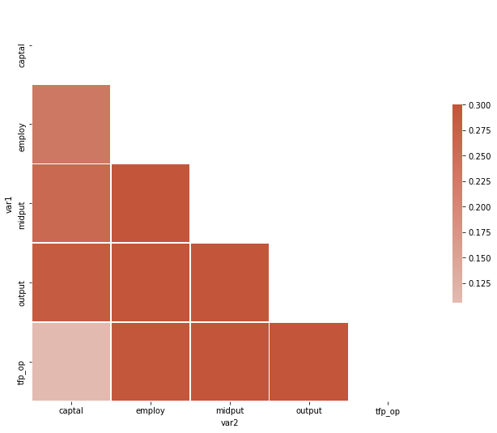

## Scatterplot

From the correlation plot above, pick up a $y$ variables.

Besides, to avoid loading all the table, we have implemented the following rule:

if the size of the table is above >150K rows, then we randomly load 150K rows

First of all, you need to define the Y-axis variables

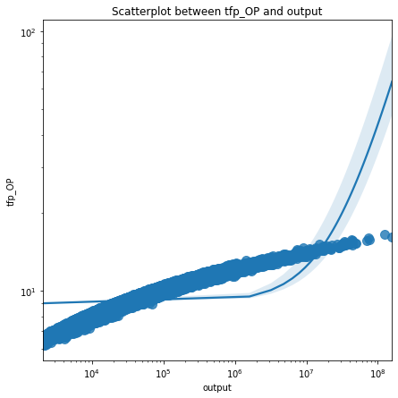

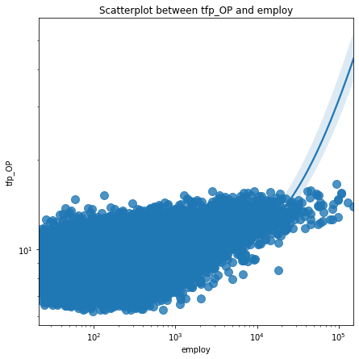

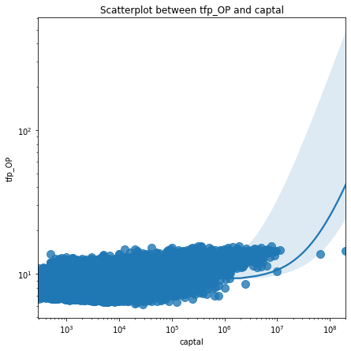

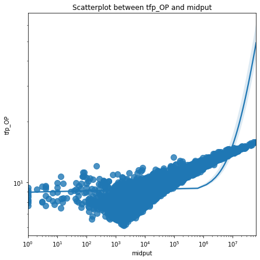

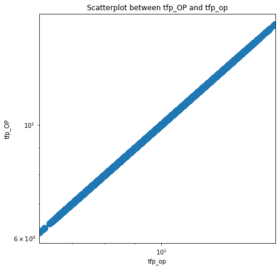

### Diverging bars

The diverging bar plot is plotting for the variables to succeed the Anova test

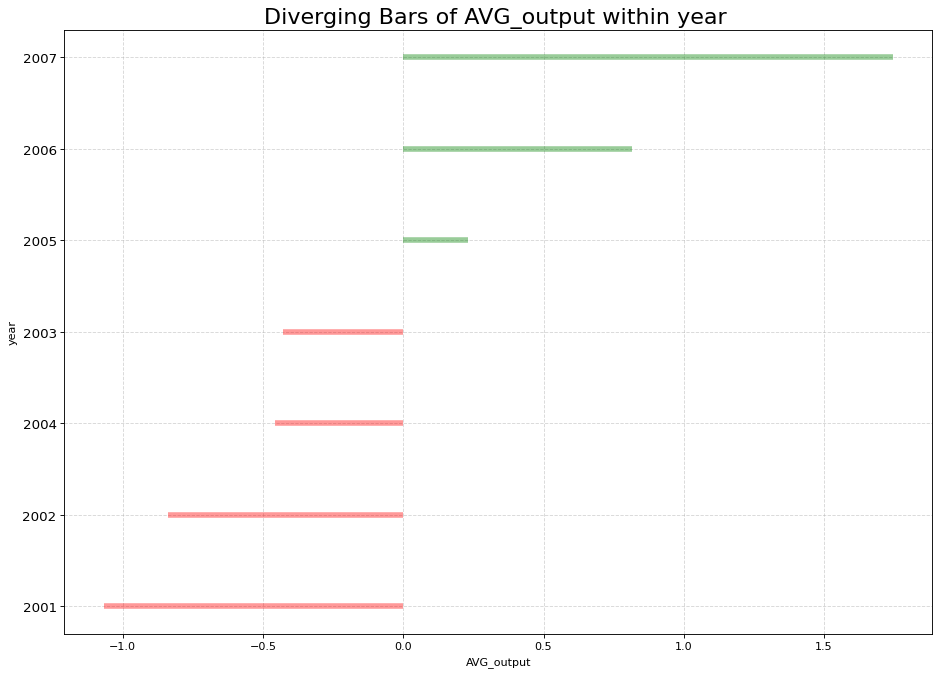

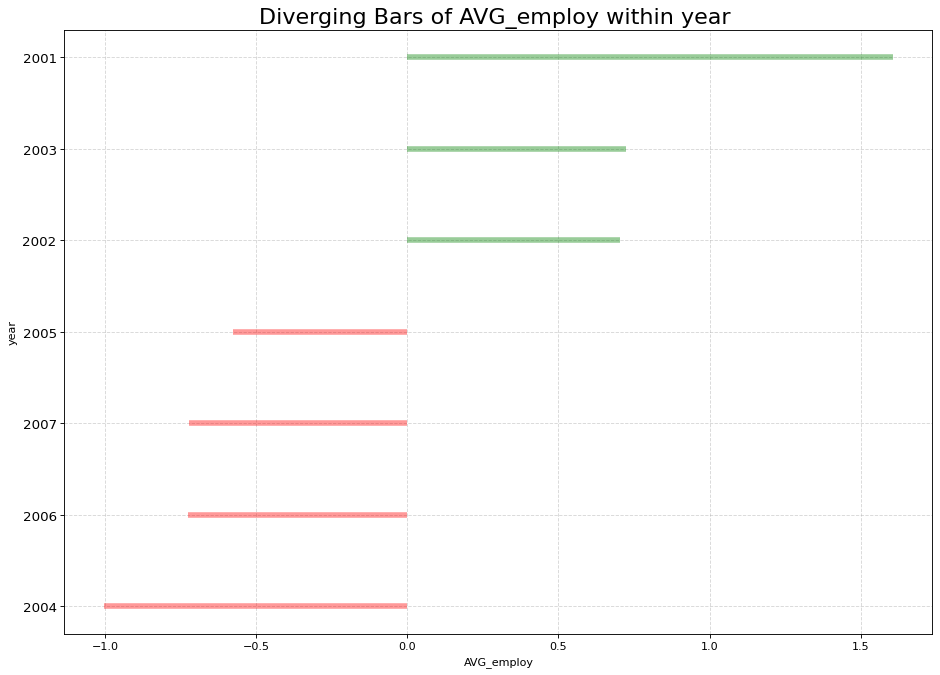

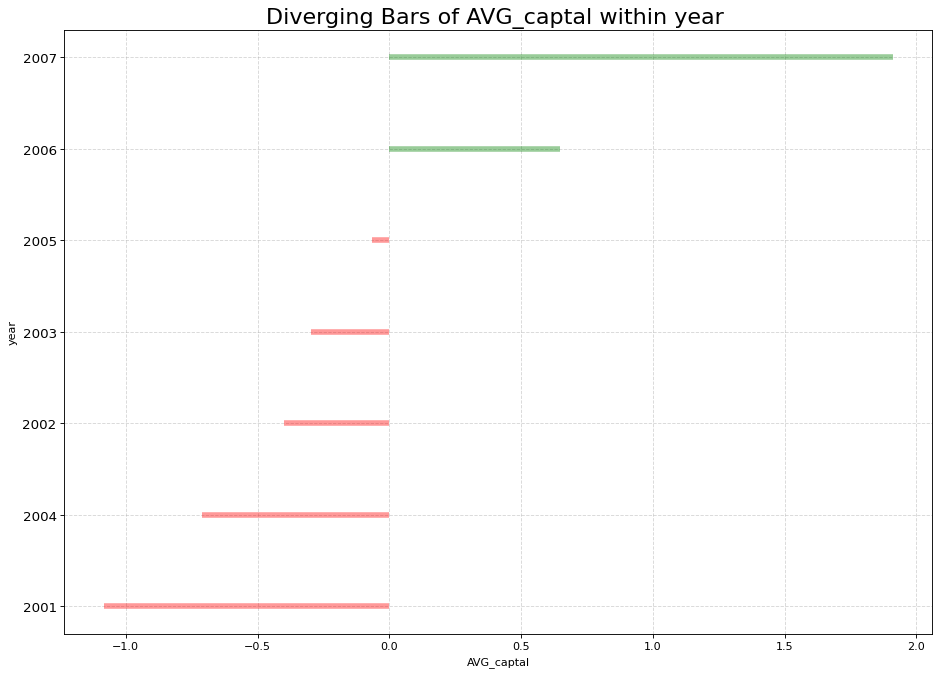

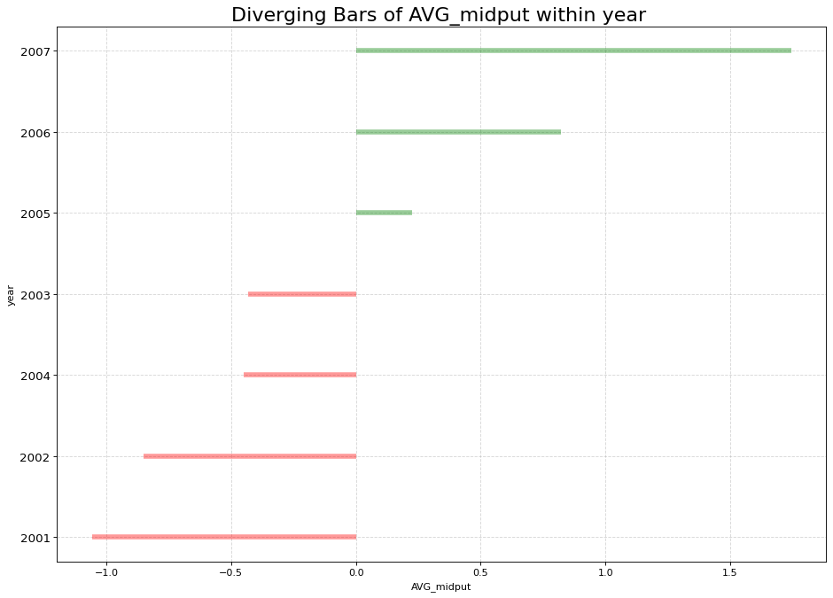

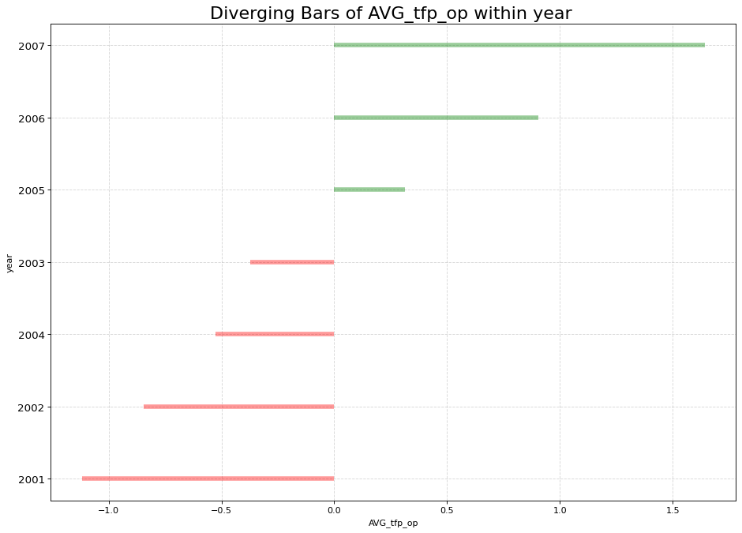